# MATH9102-W4-Difference-2Groups-Lab

## Difference in Life Satisfaction scores for respondents who said they had children and those who said they did not

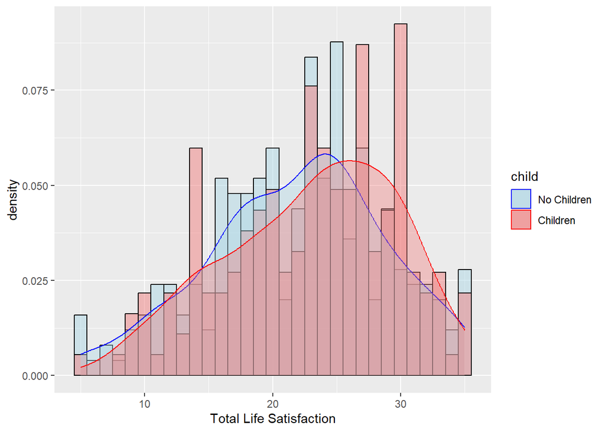

Figure 7: Histogram of Total Life Satisfaction Scores Grouped by Respondent’s Children Status

```r
# Create a separate histogram showing the distribution for the two (potentially) separate populations (the groups)
# Create the plot with both histogram and density plot
ggplot(cleaned_survey, aes(x=tlifesat, color=child, fill=child))  +
  labs(x="Total Life Satisfaction") +
  # Histogram with alpha for transparency
  geom_histogram(aes(y = ..density..), position="identity", alpha=0.5, binwidth=1, color="black") +
  # Density plot with transparency for overlapping curves
  geom_density(alpha=0.4) +
  # Customize the color and fill scales
  scale_color_manual(values=c("blue", "red"), labels=c("No Children", "Children")) +
  scale_fill_manual(values=c("lightblue", "lightcoral"), labels=c("No Children", "Children"))
```

```r
#Get descriptive statistics by group - output as a matrix
desc_stats <- psych::describeBy(survey$tlifesat, survey$child, mat=TRUE)

# Display as a formatted table
knitr::kable(desc_stats, digits = 2)
```

|  | item | group1 | vars | n | mean | sd | median | trimmed | mad | min | max | range | skew | kurtosis | se |
| --- | --- | --- | --- | --- | --- | --- | --- | --- | --- | --- | --- | --- | --- | --- | --- |
| X11 | 1 | NO | 1 | 251 | 21.91 | 6.85 | 23 | 22.1 | 7.41 | 5 | 35 | 30 | -0.26 | -0.38 | 0.43 |
| X12 | 2 | YES | 1 | 184 | 23.00 | 6.64 | 24 | 23.3 | 7.41 | 5 | 35 | 30 | -0.39 | -0.62 | 0.49 |

Table 3: Descriptive Statistics of Total Life Satisfaction Scores Grouped by Respndent’s Children Status

```r
#Conduct Levene's test for homogeneity of variance in library car - the null hypothesis is that variances in groups are equal so to assume homogeneity we would expect probability to not be statistically significant.
car::leveneTest(tlifesat ~ child, data=survey)
```

```
Levene's Test for Homogeneity of Variance (center = median)
       Df F value Pr(>F)
group   1  0.0347 0.8524
      433
```

```r
#Pr(>F) is your probability - in this case it is not statistically significant so we can assume homogeneity


#Conduct the t-test from package stats - basic r package. Prefixing it to make sure that is the one used rather than t-test from another package.

#In this case we can use the var.equal = TRUE option to specify unequal variances
stats::t.test(tlifesat~child,var.equal=TRUE,data=survey)
```

```
    Two Sample t-test

data:  tlifesat by child
t = -1.6636, df = 433, p-value = 0.09692
alternative hypothesis: true difference in means between group NO and group YES is not equal to 0
95 percent confidence interval:
 -2.3813528  0.1980858
sample estimates:
 mean in group NO mean in group YES
         21.90837          23.00000
```

```r
#No statistically significant difference was found

res <- stats::t.test(tlifesat~child,var.equal=TRUE,data=survey)
#Calculate Cohen's d
#arithmetically
effcd=round((2*res$statistic)/sqrt(res$parameter),2)

#Alternate approach -Using function from effectsize package to convert t to Cohen's d
effectsize::t_to_d(t = res$statistic, res$parameter)
```

```
d     |        95% CI
---------------------
-0.16 | [-0.35, 0.03]
```

```r
#Calculate eta squared
effes=round((res$statistic*res$statistic)/((res$statistic*res$statistic)+(res$parameter)),3)
effes
```

```
    t
0.006
```

### Reporting the results with Cohen’s d effect

An independent-samples t-test was conducted to compare total life satisfaction scores for respondents who have children and those who do not. Levene’s test for equality of variances was not statistically significant, indicating that the assumption of homogeneity of variance was met (p > 0.05). No significant difference in the scores for total life satisfaction was found (M=23.00, SD=6.64, n=184 for respondents who have children, M=21.91, SD= 6.86, n=251 for respondents who do not), (t(433)= -1.664, p = 0.1. Cohen’s d also indicated a very small effect size (-0.16). There is therefore no evidence to support rejecting the null hypothesis in favour of the alternate hypothesis, suggesting that there is no difference between total life satisfaction scores for respondents who have children and those who do not.

### Reporting the results with eta squared effect

An independent-samples t-test was conducted to compare total life satisfaction for respondents who had children and those who do not. Levene’s test for equality of variances was not statistically significant, indicating that the assumption of homogeneity of variance was met (p > .05). No significant difference in the scores for total life satisfaction was found (M=23.00, SD=6.64, n=184 for respondents who have children, M=21.91, SD= 6.86, n=251 for respondents who do not), (t(433)= -1.664, p = 0.1. A very small effect size was also indicted by the eta squared value (0.006). There is therefore no evidence to support rejecting the null hypothesis in favour of the alternate hypothesis, suggesting that there is no difference between total life satisfaction scores for respondents who have children and those who do not.